# Titanic data Exploration and Visualization

## Introduction

This project will be focused on the titanic dataset, my goal is to see what might affect somebody surviving or not. so since it data analysis project logically it goes through The Data Analytics Workflow, first import and explore the data, then come clean the data, here where get rid of missing values, duplicates and outliers, then analyze and interpret the data and finally communicate.

- 1.Importing necessary modules and libraries
- 2.Data Exploration
- 3.Data cleaning
- 4.Analysis and Data Vizualization
- 5.conclusion

## 1.Importing necessary modules and libraries

```python
from IPython.display import HTML


import pandas as pd
import matplotlib.pyplot as plt
import seaborn as sns
import numpy as np
%matplotlib inline
```

## 2.Data Exploration

```python
#Understand the data
titanic_df=pd.read_csv('train.csv')
titanic_df.head()
```

|  | PassengerId | Survived | Pclass | Name | Sex | Age | SibSp | Parch | Ticket | Fare | Cabin | Embarked |
| --- | --- | --- | --- | --- | --- | --- | --- | --- | --- | --- | --- | --- |
| 0 | 1 | 0 | 3 | Braund, Mr. Owen Harris | male | 22.0 | 1 | 0 | A/5 21171 | 7.2500 | NaN | S |
| 1 | 2 | 1 | 1 | Cumings, Mrs. John Bradley (Florence Briggs Th... | female | 38.0 | 1 | 0 | PC 17599 | 71.2833 | C85 | C |
| 2 | 3 | 1 | 3 | Heikkinen, Miss. Laina | female | 26.0 | 0 | 0 | STON/O2. 3101282 | 7.9250 | NaN | S |
| 3 | 4 | 1 | 1 | Futrelle, Mrs. Jacques Heath (Lily May Peel) | female | 35.0 | 1 | 0 | 113803 | 53.1000 | C123 | S |
| 4 | 5 | 0 | 3 | Allen, Mr. William Henry | male | 35.0 | 0 | 0 | 373450 | 8.0500 | NaN | S |

Every row is unique passenger has their name, age, etc...

### Data Dictionary

| Variable | Definition | Key |
| --- | --- | --- |
| PassengerId | Passenger |  |
| survival | Survival | 0 = No, 1 = Yes |
| Pclass | Ticket class | 1 = 1st, 2 = 2nd, 3 = 3rd |
| Name | Name of Passenger |  |
| Sex | Sex |  |
| Age | Age in years |  |
| Sibsp | # of siblings / spouses aboard the Titanic |  |
| Parch | # of parents / children aboard the Titanic |  |
| Ticket | Ticket number |  |
| Fare | Passenger fare |  |
| Cabin | Cabin number |  |
| Embarked | Port of Embarkation | C = Cherbourg, Q = Queenstown, S = Southampton |

### What is the structure of your dataset?

There are 891 passengers in the dataset with 12 features. There are three categorical variable (survival, Pclass, embarked) showed above and the rest features are passengers information.

### What is/are the main feature(s) of interest in your dataset?

I'm interested in categorical features and their effect on survival rate.

### What features in the dataset do you think will help support your investigation into your feature(s) of interest?

I expect that classes and gender will have the strongest effect on the survival rate.

```python
#checking for:
#number of columns and rows
#Data type
#Missing value
titanic_df.info()
```

```
<class 'pandas.core.frame.DataFrame'>
RangeIndex: 891 entries, 0 to 890
Data columns (total 12 columns):
 #   Column       Non-Null Count  Dtype
---  ------       --------------  -----
 0   PassengerId  891 non-null    int64
 1   Survived     891 non-null    int64
 2   Pclass       891 non-null    int64
 3   Name         891 non-null    object
 4   Sex          891 non-null    object
 5   Age          714 non-null    float64
 6   SibSp        891 non-null    int64
 7   Parch        891 non-null    int64
 8   Ticket       891 non-null    object
 9   Fare         891 non-null    float64
 10  Cabin        204 non-null    object
 11  Embarked     889 non-null    object
dtypes: float64(2), int64(5), object(5)
memory usage: 83.7+ KB
```

As you can see the data have 12 columns and 891 rows, and the Age column is a float that may not affect analysis but nothing wrong if change it to integer, and Age, Cabin, and Embarked have missing values that need to deal with.

## 3.Data cleaning

```python
#count up the number of null values
titanic_df.isnull().sum()
```

```
PassengerId      0
Survived         0
Pclass           0
Name             0
Sex              0
Age            177
SibSp            0
Parch            0
Ticket           0
Fare             0
Cabin          687
Embarked         2
dtype: int64
```

The total nulls values are 866, 177 are in the age column, 687 are in the cabin column, and 2 are in the Embarked column.The missing values in the Embarked can be ignored, for the age interpolate it not a bad idea, and for the Cabin that has a lot of nulls, could fill it with Nan string to categorizes cabin columns by the first letter if need it.

```python
#Interpolate Age column
titanic_df['Age']=titanic_df['Age'].interpolate()
```

```python
#fill Null with Nan string
titanic_df['Cabin']=titanic_df['Cabin'].fillna('Nan')
```

```python
titanic_df.isnull().sum()
```

```
PassengerId    0
Survived       0
Pclass         0
Name           0
Sex            0
Age            0
SibSp          0
Parch          0
Ticket         0
Fare           0
Cabin          0
Embarked       2
dtype: int64
```

That's more like it, done dealing with missing Values now time to check duplicate values and outliers.

```python
#Checking for duplicate
titanic_df.duplicated().sum()
```

```
0
```

```python
#checking outliers for numerical columns
numerical_list=['Age','SibSp','Parch','Fare'] #list of numerical values to check for outliers
titanic_df[numerical_list].describe()
```

|  | Age | SibSp | Parch | Fare |
| --- | --- | --- | --- | --- |
| count | 891.000000 | 891.000000 | 891.000000 | 891.000000 |
| mean | 29.726061 | 0.523008 | 0.381594 | 32.204208 |
| std | 13.902353 | 1.102743 | 0.806057 | 49.693429 |
| min | 0.420000 | 0.000000 | 0.000000 | 0.000000 |
| 25% | 21.000000 | 0.000000 | 0.000000 | 7.910400 |
| 50% | 28.500000 | 0.000000 | 0.000000 | 14.454200 |
| 75% | 38.000000 | 1.000000 | 0.000000 | 31.000000 |
| max | 80.000000 | 8.000000 | 6.000000 | 512.329200 |

No duplicates that nice, and age, Sibsp, and parch columns are all good except for the Fare column, the maximum value is 512 far from the average value, an outlier for sure, let's ignore it for now, we may not need to analyze the fare column.

## 4.Analysis and Data Vizualization

### Univariate Exploration

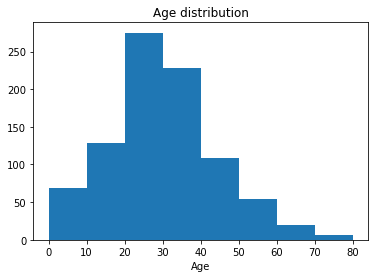

```python
#checking age distribution
bins=np.arange(0,titanic_df.Age.max()+10,10)
plt.hist(data=titanic_df,x='Age',bins=bins);
plt.title('Age distribution')
plt.xlabel('Age');
```

```python
#Checking average age for survivors
pd.pivot_table(data=titanic_df,index='Survived',values='Age')
```

| Survived | Age |
| --- | --- |
| 0 | 30.407787 |
| 1 | 28.631711 |

It seems almost half of the passenger under 30 and the average age of surviving close to who not survived, but it seems you could say, young people might have more chance of surviving.

### Discuss the distribution(s) of your variable(s) of interest. Were there any unusual points? Did you need to perform any transformations?

A High number of passengers are under 30.

no transformation was needed.

### Survival rate for categorical columns.

```python
#list of categorical values
cate_list=['Pclass','Sex','Embarked']
```

```python
#function to create pivot table
def display_pivot_table(column):
    print(pd.pivot_table(data=titanic_df,index='Survived',columns=column,values='PassengerId',aggfunc="count"))
```

```python
#function calculates Survival rate and creates a barplot for Survival rate

def rate_of_survive(column):

    display_pivot_table(column) #show pivot table for input column
    print('\n') #print new line
    for cate in titanic_df[column].value_counts().index: # for loop for uniques value inside column
        category=titanic_df[titanic_df[column]==cate]["Survived"] #sign variable for series of specific unique value
        rate_first_class=round(sum(category)/len(category)*100) #calculate rate of survive
        print(f'for {cate} the Survival rate is {rate_first_class}%')
    print('\n')
    base_color=sns.color_palette()[0]
    sns.barplot(data=titanic_df,x=column,y='Survived',color=base_color) #create barplot
    plt.title('Survived Vs {}'.format(column))
    plt.show()
```

## Class,Gender and Embarked

```
Pclass      1   2    3
Survived
0          80  97  372
1         136  87  119


for 3 the Survival rate is 24%
for 1 the Survival rate is 63%
for 2 the Survival rate is 47%
```

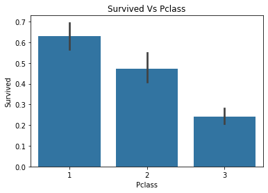

```
Sex       female  male
Survived
0             81   468
1            233   109


for male the Survival rate is 19%
for female the Survival rate is 74%
```

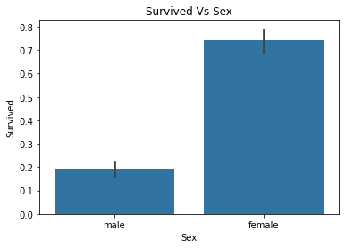

```
Embarked   C   Q    S
Survived
0         75  47  427
1         93  30  217


for S the Survival rate is 34%
for C the Survival rate is 55%
for Q the Survival rate is 39%
```

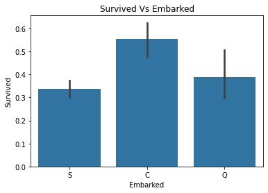

```python
#for loop use to iterating over a list
for cate in cate_list:
    rate_of_survive(cate)
```

### Mulitivariate Exploration

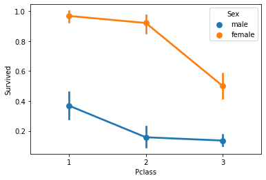

```python
#Checking survivor Vs class and gender
sns.pointplot(data=titanic_df,x='Pclass',y='Survived',hue='Sex')
```

The first class has the highest survival rate for both genders.

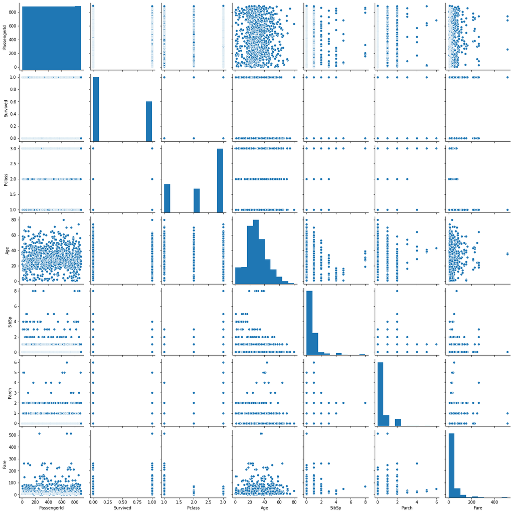

```python
#check if there any Positive or negative correlation between columns
sns.pairplot(titanic_df)
```

### Talk about some of the relationships you observed in this part of the investigation. How did the feature(s) of interest vary with other features in the dataset?

Females and males from the first class have a higher chance compare to others.